# Project:

# Relations between Alcohol and Tobacco consuption vs. Fertility levels and Car exidents mortality - Gapminder World

- Introduction
- Data Wrangling
- Exploratory Data Analysis
- Conclusions

## Introduction

Selected data set was downloaded from Gapminder website - http://www.gapminder.org/. It is comprised of four excel spreadsheets of car_RTI_age_indicator, alcohol_consumption_indicator, tobacco_consumption_indicator, total_fertility_rate_indicator. In order to build the bubble scatter plots addiional data on GDP per capita was downloaded.

The data downloaded was then used to answer the questions such as:

1) What countries that have the lowest/highest GDP have lowest/highest average fertility level? How does it correspond to acohol or tobacco consumption data? Is this affected by GDP?

2) What countries that have the lowest/highest GDP have lowest/highest car crash statistics? How does it correspond to acohol or tobacco consumption data? Is this affected by GDP?

3) What countries that have the lowest/highest GDP have lowest/highest alco/tobacco consumption and is there any correlation between high/low alcohol and tobacco consumption?

```python
# Use this cell to set up import statements for all of the packages that you
#   plan to use.
import matplotlib.pyplot as plt
import pandas as pd
import numpy as np
%matplotlib inline
```

## Data Wrangling

### General Properties

```python
# Loads data on car mortality and prints out a few lines.
car_age= pd.read_csv('car_RTI_age_indicator.csv')
car_age.head(2)
```

|  | Car mortality per 100,000, age adjusted | 1985 | 1986 | 1987 | 1988 | 1989 | 1990 | 1991 | 1992 | 1993 | ... | 1999 | 2000 | 2001 | 2002 | 2003 | 2004 | 2005 | 2006 | 2007 | 2008 |
| --- | --- | --- | --- | --- | --- | --- | --- | --- | --- | --- | --- | --- | --- | --- | --- | --- | --- | --- | --- | --- | --- |
| 0 | Albania | NaN | NaN | NaN | NaN | NaN | NaN | NaN | NaN | NaN | ... | NaN | NaN | NaN | NaN | NaN | NaN | NaN | 5.977778 | NaN | NaN |
| 1 | Argentina | NaN | NaN | NaN | NaN | NaN | NaN | NaN | NaN | NaN | ... | 10.907 | 9.882 | 8.653 | 7.383 | 7.96 | 8.216 | 8.383 | 8.971000 | 8.682 | NaN |

2 rows × 25 columns

```python
# Uses .info function to inspect data
#  types and look for instances of missing or possibly errant data.
car_age.info()
```

```
<class 'pandas.core.frame.DataFrame'>
RangeIndex: 148 entries, 0 to 147
Data columns (total 25 columns):
Car mortality per 100,000, age adjusted    148 non-null object
1985                                       1 non-null float64
1986                                       1 non-null float64
1987                                       1 non-null float64
1988                                       2 non-null float64
1989                                       2 non-null float64
1990                                       2 non-null float64
1991                                       4 non-null float64
1992                                       4 non-null float64
1993                                       4 non-null float64
1994                                       8 non-null float64
1995                                       14 non-null float64
1996                                       28 non-null float64
1997                                       46 non-null float64
1998                                       55 non-null float64
1999                                       63 non-null float64
2000                                       68 non-null float64
2001                                       68 non-null float64
2002                                       64 non-null float64
2003                                       62 non-null float64
2004                                       62 non-null float64
2005                                       60 non-null float64
2006                                       63 non-null float64
2007                                       106 non-null float64
2008                                       21 non-null float64
dtypes: float64(24), object(1)
memory usage: 29.0+ KB
```

```python
# Loads data on alcohol consumption and prints out a few lines.
alc_csn= pd.read_csv('alcohol_consumption_indicator.csv')
alc_csn.head(2)
```

|  | Unnamed: 0 | 1985 | 1986 | 1987 | 1988 | 1989 | 1990 | 1991 | 1992 | 1993 | ... | 1999 | 2000 | 2001 | 2002 | 2003 | 2004 | 2005 | 2006 | 2007 | 2008 |
| --- | --- | --- | --- | --- | --- | --- | --- | --- | --- | --- | --- | --- | --- | --- | --- | --- | --- | --- | --- | --- | --- |
| 0 | Afghanistan | NaN | NaN | NaN | NaN | NaN | NaN | NaN | NaN | NaN | ... | NaN | NaN | NaN | NaN | NaN | NaN | 0.02 | NaN | NaN | 0.03 |
| 1 | Albania | NaN | NaN | NaN | NaN | NaN | NaN | NaN | NaN | NaN | ... | NaN | NaN | NaN | NaN | NaN | NaN | 6.68 | NaN | NaN | 7.29 |

2 rows × 25 columns

```python
# Uses .info function to inspect data
#  types and look for instances of missing or possibly errant data.
alc_csn.info()
```

```
<class 'pandas.core.frame.DataFrame'>
RangeIndex: 189 entries, 0 to 188
Data columns (total 25 columns):
Unnamed: 0    189 non-null object
1985          1 non-null float64
1986          1 non-null float64
1987          1 non-null float64
1988          1 non-null float64
1989          1 non-null float64
1990          4 non-null float64
1991          1 non-null float64
1992          2 non-null float64
1993          4 non-null float64
1994          6 non-null float64
1995          4 non-null float64
1996          2 non-null float64
1997          0 non-null float64
1998          1 non-null float64
1999          0 non-null float64
2000          1 non-null float64
2001          1 non-null float64
2002          1 non-null float64
2003          1 non-null float64
2004          1 non-null float64
2005          188 non-null float64
2006          1 non-null float64
2007          1 non-null float64
2008          187 non-null float64
dtypes: float64(24), object(1)
memory usage: 37.0+ KB
```

```python
# Loads data on fertility levels and prints out a few lines.
tot_fert=pd.read_csv('total_fertility_rate_indicator.csv',encoding = "ISO-8859-1")
tot_fert.head(2)
```

|  | TFR with projections | 1545 | 1586 | 1614 | 1635 | 1644 | 1657 | 1704 | 1709 | 1717 | ... | 2021 | 2022 | 2023 | 2024 | 2030 | 2040 | 2050 | 2070 | 2080 | 2099 |
| --- | --- | --- | --- | --- | --- | --- | --- | --- | --- | --- | --- | --- | --- | --- | --- | --- | --- | --- | --- | --- | --- |
| 0 | Abkhazia | NaN | NaN | NaN | NaN | NaN | NaN | NaN | NaN | NaN | ... | NaN | NaN | NaN | NaN | NaN | NaN | NaN | NaN | NaN | NaN |
| 1 | Afghanistan | NaN | NaN | NaN | NaN | NaN | NaN | NaN | NaN | NaN | ... | 3.502 | 3.375 | 3.258 | 3.151 | 2.67 | 2.193 | 1.912 | 1.701 | 1.705 | 1.759 |

2 rows × 250 columns

```python
# Uses .info function to inspect data
#  types and look for instances of missing or possibly errant data.
tot_fert.info()
```

```
<class 'pandas.core.frame.DataFrame'>
RangeIndex: 260 entries, 0 to 259
Columns: 250 entries, TFR with projections to 2099
dtypes: float64(249), object(1)
memory usage: 507.9+ KB
```

```python
# Loads data on tobacco consumption and prints out a few lines.
tbc_csn= pd.read_csv('tobacco_consumption.csv')
tbc_csn.head(2)
```

|  | Prevalence of current tobacco use among adults (>=15 years) (%) both sexes | 2002 | 2005 | Unnamed: 3 | Unnamed: 4 |
| --- | --- | --- | --- | --- | --- |
| 0 | Algeria | 15.2 | 15.2 | NaN | NaN |
| 1 | Angola | NaN | NaN | NaN | NaN |

```python
# Uses .info function to inspect data
#  types and look for instances of missing or possibly errant data.
tbc_csn.info()
```

```
<class 'pandas.core.frame.DataFrame'>
RangeIndex: 193 entries, 0 to 192
Data columns (total 5 columns):
Prevalence of current tobacco use among adults (>=15 years) (%) both sexes    192 non-null object
2002                                                                          129 non-null float64
2005                                                                          129 non-null float64
Unnamed: 3                                                                    0 non-null float64
Unnamed: 4                                                                    0 non-null float64
dtypes: float64(4), object(1)
memory usage: 7.6+ KB
```

```python
# Loads data on GDP with specified encoding  and prints out a few lines.
gdp_cap= pd.read_csv('indicator gdppercapita.csv',encoding = "ISO-8859-1")
gdp_cap.head(2)
```

|  | GDP per capita PPP, with projections | 1764 | 1765 | 1766 | 1767 | 1768 | 1769 | 1770 | 1771 | 1772 | ... | 2009 | 2010 | 2011 | 2012 | 2013 | 2014 | 2015 | 2016 | 2017 | 2018 |
| --- | --- | --- | --- | --- | --- | --- | --- | --- | --- | --- | --- | --- | --- | --- | --- | --- | --- | --- | --- | --- | --- |
| 0 | Abkhazia | NaN | NaN | NaN | NaN | NaN | NaN | NaN | NaN | NaN | ... | NaN | NaN | NaN | NaN | NaN | NaN | NaN | NaN | NaN | NaN |
| 1 | Afghanistan | NaN | NaN | NaN | NaN | NaN | NaN | NaN | NaN | NaN | ... | 1154.859365 | 1214.613653 | 1261.354184 | 1349.696941 | 1351.014534 | 1374.066507 | 1417.760346 | 1461.588637 | 1500.605759 | 1527.470197 |

2 rows × 256 columns

```python
# Uses .info function to inspect data
#  types and look for instances of missing or possibly errant data.
gdp_cap.info()
```

```
<class 'pandas.core.frame.DataFrame'>
RangeIndex: 260 entries, 0 to 259
Columns: 256 entries, GDP per capita PPP, with projections to 2018
dtypes: float64(255), object(1)
memory usage: 520.1+ KB
```

### Data Cleaning Process - Car mortality data

Since the data sheets were not consistent with years and the set of countries they were filtered from 1995 to 2008 years. In addition lots of data fields were N/A and they were dropped.

This data cleaning resulted in list of 95 conries for 2007 for 2005 for tobacco, alco consuption, fertility, gdp levels, and ranging numbers of contries for car_crash_indicator (from 7 to 69 in selected contries)

The column names were also cleaned, as well as Average, Min and Max values were calculated in order to make an easier visualization after.

In this cell I have renamed contry field from car crash data, droped values older then 1995, calculated Mean, Min and Max for each contry, then added the index '_car' to each of resulting columns.

```python
# rename contry column from car crash data
car_age.rename(columns={'Car mortality per 100,000, age adjusted': 'cntry'}, inplace=True)

# drop values older then 1995
car_age=car_age.drop (car_age.loc[:,'1985':'1994'], 1)

# calculates Mean, Min and Max for each contry
car_age['Average']=car_age.loc[:, :].mean(axis=1)
car_age['Minimum']=car_age.loc[:,:].min(axis=1)
car_age['Maximum']=car_age.loc[:,:].max(axis=1)

#add the index '_car' to each of resulting columns
car_age.rename(columns=lambda x: x[:10] + "_car", inplace=True)

# rename contry column from car crash data
car_age.rename(columns={'cntry_car': 'cntry'}, inplace=True)

#double check the result
car_age.info()
```

```
<class 'pandas.core.frame.DataFrame'>
RangeIndex: 148 entries, 0 to 147
Data columns (total 18 columns):
cntry          148 non-null object
1995_car       14 non-null float64
1996_car       28 non-null float64
1997_car       46 non-null float64
1998_car       55 non-null float64
1999_car       63 non-null float64
2000_car       68 non-null float64
2001_car       68 non-null float64
2002_car       64 non-null float64
2003_car       62 non-null float64
2004_car       62 non-null float64
2005_car       60 non-null float64
2006_car       63 non-null float64
2007_car       106 non-null float64
2008_car       21 non-null float64
Average_car    148 non-null float64
Minimum_car    148 non-null float64
Maximum_car    148 non-null float64
dtypes: float64(17), object(1)
memory usage: 20.9+ KB
```

### Data Cleaning Process - Alcohol consumption data

In the following two cells I have renamed contry field from alcohol consumption data, dropped values older then 1995, calculated Mean, Min and Max for each contry, then added the index '_alc' to each of resulting columns. Finally I have dropped contries that had no values associated with them

```python
# rename contry field from alcohol consumption data
alc_csn.rename(columns={'Unnamed: 0': 'cntry'}, inplace=True)

# Check the data
alc_csn.info()
```

```
<class 'pandas.core.frame.DataFrame'>
RangeIndex: 189 entries, 0 to 188
Data columns (total 25 columns):
cntry    189 non-null object
1985     1 non-null float64
1986     1 non-null float64
1987     1 non-null float64
1988     1 non-null float64
1989     1 non-null float64
1990     4 non-null float64
1991     1 non-null float64
1992     2 non-null float64
1993     4 non-null float64
1994     6 non-null float64
1995     4 non-null float64
1996     2 non-null float64
1997     0 non-null float64
1998     1 non-null float64
1999     0 non-null float64
2000     1 non-null float64
2001     1 non-null float64
2002     1 non-null float64
2003     1 non-null float64
2004     1 non-null float64
2005     188 non-null float64
2006     1 non-null float64
2007     1 non-null float64
2008     187 non-null float64
dtypes: float64(24), object(1)
memory usage: 37.0+ KB
```

```python
# Since there are only two columns with significant data we need to filter them
alc_csn=alc_csn.drop (alc_csn.loc[:,'1985':'2004'], 1)
alc_csn=alc_csn.drop (alc_csn.loc[:,'2006':'2007'], 1)

# calculates Mean, Min and Max for each contry
alc_csn['Average']=alc_csn.loc[:, :].mean(axis=1)
alc_csn['Minimum']=alc_csn.loc[:,:].min(axis=1)
alc_csn['Maximum']=alc_csn.loc[:,:].max(axis=1)

#add the index '_alc' to each of resulting columns
alc_csn.rename(columns=lambda x: x[:10] + "_alc", inplace=True)

# rename contry field from alcohol consumption data,
alc_csn.rename(columns={'cntry_alc': 'cntry'}, inplace=True)

# Drop all contries that hasnt got any data
alc_csn=alc_csn.dropna(axis=0, how ='any')
alc_csn.info()
```

```
<class 'pandas.core.frame.DataFrame'>
Int64Index: 186 entries, 0 to 188
Data columns (total 6 columns):
cntry          186 non-null object
2005_alc       186 non-null float64
2008_alc       186 non-null float64
Average_alc    186 non-null float64
Minimum_alc    186 non-null float64
Maximum_alc    186 non-null float64
dtypes: float64(5), object(1)
memory usage: 10.2+ KB
```

### Data Cleaning Process - Fertility data

In the following two cells I have renamed contry field from fertility data, dropped values older then 1995, calculated Mean, Min and Max for each contry, then added the index '_fert' to each of resulting columns. Finally I have dropped contries that had no values associated with them

```python
# rename contry field from alcohol consumption data
tot_fert.rename(columns={'TFR with projections': 'cntry'}, inplace=True)
# check the result
tot_fert.head()
```

|  | cntry | 1545 | 1586 | 1614 | 1635 | 1644 | 1657 | 1704 | 1709 | 1717 | ... | 2021 | 2022 | 2023 | 2024 | 2030 | 2040 | 2050 | 2070 | 2080 | 2099 |
| --- | --- | --- | --- | --- | --- | --- | --- | --- | --- | --- | --- | --- | --- | --- | --- | --- | --- | --- | --- | --- | --- |
| 0 | Abkhazia | NaN | NaN | NaN | NaN | NaN | NaN | NaN | NaN | NaN | ... | NaN | NaN | NaN | NaN | NaN | NaN | NaN | NaN | NaN | NaN |
| 1 | Afghanistan | NaN | NaN | NaN | NaN | NaN | NaN | NaN | NaN | NaN | ... | 3.502 | 3.375 | 3.258 | 3.151 | 2.670 | 2.193 | 1.912 | 1.701 | 1.705 | 1.759 |
| 2 | Akrotiri and Dhekelia | NaN | NaN | NaN | NaN | NaN | NaN | NaN | NaN | NaN | ... | NaN | NaN | NaN | NaN | NaN | NaN | NaN | NaN | NaN | NaN |
| 3 | Albania | NaN | NaN | NaN | NaN | NaN | NaN | NaN | NaN | NaN | ... | 1.760 | 1.757 | 1.754 | 1.752 | 1.742 | 1.740 | 1.750 | 1.789 | 1.809 | 1.841 |
| 4 | Algeria | NaN | NaN | NaN | NaN | NaN | NaN | NaN | NaN | NaN | ... | 2.398 | 2.362 | 2.328 | 2.296 | 2.142 | 1.988 | 1.920 | 1.887 | 1.888 | 1.896 |

5 rows × 250 columns

```python
# Slices the data into selected set from 1995 to 2008 and leaves cntry column in index
tot_fert=tot_fert.set_index('cntry')
tot_fert=tot_fert.loc[:, "1995":'2008']

# Reset index to see the cntry column
tot_fert=tot_fert.reset_index()

# calculates Mean, Min and Max for each contry
tot_fert['Average']=tot_fert.loc[:, :].mean(axis=1)
tot_fert['Minimum']=tot_fert.loc[:,:].min(axis=1)
tot_fert['Maximum']=tot_fert.loc[:,:].max(axis=1)

#add the index '_fert' to each of resulting columns
tot_fert.rename(columns=lambda x: x[:10] + "_fert", inplace=True)

# rename contry field to cntry
tot_fert.rename(columns={'cntry_fert': 'cntry'}, inplace=True)

# Drop all contries that hasn't got any data
tot_fert=tot_fert.dropna(axis=0, how ='any')

# Check result
tot_fert.info()
```

```
<class 'pandas.core.frame.DataFrame'>
Int64Index: 202 entries, 1 to 258
Data columns (total 18 columns):
cntry           202 non-null object
1995_fert       202 non-null float64
1996_fert       202 non-null float64
1997_fert       202 non-null float64
1998_fert       202 non-null float64
1999_fert       202 non-null float64
2000_fert       202 non-null float64
2001_fert       202 non-null float64
2002_fert       202 non-null float64
2003_fert       202 non-null float64
2004_fert       202 non-null float64
2005_fert       202 non-null float64
2006_fert       202 non-null float64
2007_fert       202 non-null float64
2008_fert       202 non-null float64
Average_fert    202 non-null float64
Minimum_fert    202 non-null float64
Maximum_fert    202 non-null float64
dtypes: float64(17), object(1)
memory usage: 30.0+ KB
```

### Data Cleaning Process - Tobacco consumption data

In the following two cells I have renamed contry field from tobacco consumption data, dropped values older then 1995, calculated Mean, Min and Max for each contry, then added the index '_tbc' to each of resulting columns. Finally I have dropped contries that had no values associated with them

```python
# rename contry field from alcohol consumption data
tbc_csn.rename(columns={'Prevalence of current tobacco use among adults (>=15 years) (%) both sexes': 'cntry'}, inplace=True)

# check the result
tbc_csn.info()
```

```
<class 'pandas.core.frame.DataFrame'>
RangeIndex: 193 entries, 0 to 192
Data columns (total 5 columns):
cntry         192 non-null object
2002          129 non-null float64
2005          129 non-null float64
Unnamed: 3    0 non-null float64
Unnamed: 4    0 non-null float64
dtypes: float64(4), object(1)
memory usage: 7.6+ KB
```

```python
# Slices the data into selected set from 1995 to 2008 and leaves cntry column in index
tbc_csn=tbc_csn.set_index('cntry')
tbc_csn=tbc_csn.loc[:, "1995":'2008']

# Reset index to see the cntry column
tbc_csn=tbc_csn.reset_index()

# calculates Mean, Min and Max for each contry
tbc_csn['Average']=tbc_csn.loc[:, :].mean(axis=1)
tbc_csn['Minimum']=tbc_csn.loc[:,:].min(axis=1)
tbc_csn['Maximum']=tbc_csn.loc[:,:].max(axis=1)

#add the index '_tbc' to each of resulting columns
tbc_csn.rename(columns=lambda x: x[:10] + "_tbc", inplace=True)

# rename contry field to cntry
tbc_csn.rename(columns={'cntry_tbc': 'cntry'}, inplace=True)

# Drop all contries that hasn't got any data
tbc_csn=tbc_csn.dropna(axis=0, how ='any')

# Check result
tbc_csn.info()
```

```
<class 'pandas.core.frame.DataFrame'>
Int64Index: 129 entries, 0 to 191
Data columns (total 6 columns):
cntry          129 non-null object
2002_tbc       129 non-null float64
2005_tbc       129 non-null float64
Average_tbc    129 non-null float64
Minimum_tbc    129 non-null float64
Maximum_tbc    129 non-null float64
dtypes: float64(5), object(1)
memory usage: 7.1+ KB
```

### Data Cleaning Process - GDP data

In the following two cells I have renamed contry field from alcohol consumption data, dropped values older then 1995, calculated Mean, Min and Max for each contry.

Additionally I have run the . describe function to see the Min, 25,50,75 %%, Max distributions to build cells that will be used as limits for the GDP. This newely created levels will be used in bubble plot creation.

Then I've added the index '_gdp' to each of resulting columns. Finally I have dropped contries that had no values associated with them

```python
# rename contry field from alcohol consumption data
gdp_cap.rename(columns={'GDP per capita PPP, with projections': 'cntry'}, inplace=True)

# check the result
gdp_cap.head()
```

|  | cntry | 1764 | 1765 | 1766 | 1767 | 1768 | 1769 | 1770 | 1771 | 1772 | ... | 2009 | 2010 | 2011 | 2012 | 2013 | 2014 | 2015 | 2016 | 2017 | 2018 |
| --- | --- | --- | --- | --- | --- | --- | --- | --- | --- | --- | --- | --- | --- | --- | --- | --- | --- | --- | --- | --- | --- |
| 0 | Abkhazia | NaN | NaN | NaN | NaN | NaN | NaN | NaN | NaN | NaN | ... | NaN | NaN | NaN | NaN | NaN | NaN | NaN | NaN | NaN | NaN |
| 1 | Afghanistan | NaN | NaN | NaN | NaN | NaN | NaN | NaN | NaN | NaN | ... | 1154.859365 | 1214.613653 | 1261.354184 | 1349.696941 | 1351.014534 | 1374.066507 | 1417.760346 | 1461.588637 | 1500.605759 | 1527.470197 |
| 2 | Akrotiri and Dhekelia | NaN | NaN | NaN | NaN | NaN | NaN | NaN | NaN | NaN | ... | NaN | NaN | NaN | NaN | NaN | NaN | NaN | NaN | NaN | NaN |
| 3 | Albania | NaN | NaN | NaN | NaN | NaN | NaN | NaN | NaN | NaN | ... | 6550.896164 | 6746.445312 | 6914.267317 | 6969.306283 | 7059.456493 | 7199.943200 | 7343.225649 | 7489.359482 | 7638.401485 | 7790.409455 |
| 4 | Algeria | NaN | NaN | NaN | NaN | NaN | NaN | NaN | NaN | NaN | ... | 6173.729741 | 6300.648214 | 6354.640523 | 6419.127829 | 6534.732615 | 6658.740348 | 6796.973367 | 6948.204385 | 7107.780582 | 7273.948820 |

5 rows × 256 columns

```python
# Slices the data into selected set from 1995 to 2008 and leaves cntry column in index
gdp_cap=gdp_cap.set_index('cntry')
gdp_cap=gdp_cap.loc[:, "1995":'2008']

# calculates Mean, Min and Max for each contry
gdp_cap['Average']=gdp_cap.loc[:,:].mean(axis=1)
gdp_cap['Minimum']=gdp_cap.loc[:,:].min(axis=1)
gdp_cap['Maximum']=gdp_cap.loc[:,:].max(axis=1)
```

```python
#Use .describe to take a look at the min and max bin edges that need to be used for gdp data transformation
gdp_cap.loc[:,'Minimum':].describe()
```

|  | Minimum | Maximum |
| --- | --- | --- |
| count | 230.000000 | 230.000000 |
| mean | 10515.534650 | 14801.053561 |
| std | 12238.647453 | 16353.813665 |
| min | 281.908597 | 367.216806 |
| 25% | 1745.391441 | 2808.530047 |
| 50% | 5623.529636 | 7993.866885 |
| 75% | 16148.215135 | 23294.600953 |
| max | 62413.108280 | 95877.649220 |

```python
#Use data from .describe to fill the bin edges and assign bin names
bin_edges = [281.90, 1745.39, 5623.52, 16148.21, 95877.65]
bin_names = [1,2,3,4]

#Function that will take the gdp value from each contry on a studied
# time frame and convert it to GDP level according to bin edges
def categorize (column):
    return pd.cut(column, bin_edges, labels=bin_names)

# aply above function
gdp_cap=gdp_cap.loc[:,'1995':].apply(categorize,axis=1 )

# Reset index to see the cntry column
gdp_cap=gdp_cap.reset_index()

#add the index '_gdp' to each of resulting columns
gdp_cap.rename(columns=lambda x: x[:10] + "_gdp", inplace=True)

# rename contry field to cntry
gdp_cap.rename(columns={'cntry_gdp': 'cntry'}, inplace=True)

# Drop all contries that hasn't got any data
gdp_cap=gdp_cap.dropna(axis=0, how ='any')

# Check result
gdp_cap.info()
```

```
<class 'pandas.core.frame.DataFrame'>
Int64Index: 210 entries, 1 to 258
Data columns (total 18 columns):
cntry          210 non-null object
1995_gdp       210 non-null float64
1996_gdp       210 non-null float64
1997_gdp       210 non-null float64
1998_gdp       210 non-null float64
1999_gdp       210 non-null float64
2000_gdp       210 non-null float64
2001_gdp       210 non-null float64
2002_gdp       210 non-null float64
2003_gdp       210 non-null float64
2004_gdp       210 non-null float64
2005_gdp       210 non-null float64
2006_gdp       210 non-null float64
2007_gdp       210 non-null float64
2008_gdp       210 non-null float64
Average_gdp    210 non-null float64
Minimum_gdp    210 non-null float64
Maximum_gdp    210 non-null float64
dtypes: float64(17), object(1)
memory usage: 31.2+ KB
```

### Data Cleaning Process - Inner merge

In this cell i tried to make an inner merge to filter out all the contries that are present in all five data sets

```python
#perform inner merge between car mortality and alcohol consumption
merged_inner1 = pd.merge(car_age, alc_csn, on='cntry')

#perform inner merge merged car mortality, alcohol consumption, and fertility
merged_inner2 = pd.merge(merged_inner1, tot_fert,on='cntry')

#perform inner merge merged car mortality, alcohol consumption, fertility, and tobacco consumption
merged_inner3 = pd.merge(merged_inner2, tbc_csn,on='cntry')

#perform inner merge merged car mortality, alcohol consumption, fertility, tobacco consumption,
#and GDP levels to make a finalised data set
merged_inner = pd.merge(merged_inner3, gdp_cap,on='cntry')
```

```python
#Check the data
merged_inner.info()
```

```
<class 'pandas.core.frame.DataFrame'>
Int64Index: 95 entries, 0 to 94
Data columns (total 62 columns):
cntry           95 non-null object
1995_car        7 non-null float64
1996_car        20 non-null float64
1997_car        34 non-null float64
1998_car        42 non-null float64
1999_car        46 non-null float64
2000_car        50 non-null float64
2001_car        49 non-null float64
2002_car        46 non-null float64
2003_car        44 non-null float64
2004_car        46 non-null float64
2005_car        42 non-null float64
2006_car        51 non-null float64
2007_car        69 non-null float64
2008_car        20 non-null float64
Average_car     95 non-null float64
Minimum_car     95 non-null float64
Maximum_car     95 non-null float64
2005_alc        95 non-null float64
2008_alc        95 non-null float64
Average_alc     95 non-null float64
Minimum_alc     95 non-null float64
Maximum_alc     95 non-null float64
1995_fert       95 non-null float64
1996_fert       95 non-null float64
1997_fert       95 non-null float64
1998_fert       95 non-null float64
1999_fert       95 non-null float64
2000_fert       95 non-null float64
2001_fert       95 non-null float64
2002_fert       95 non-null float64
2003_fert       95 non-null float64
2004_fert       95 non-null float64
2005_fert       95 non-null float64
2006_fert       95 non-null float64
2007_fert       95 non-null float64
2008_fert       95 non-null float64
```

[output cut: 12 more lines]

```
1999_gdp        95 non-null float64
2000_gdp        95 non-null float64
2001_gdp        95 non-null float64
2002_gdp        95 non-null float64
2003_gdp        95 non-null float64
2004_gdp        95 non-null float64
2005_gdp        95 non-null float64
2006_gdp        95 non-null float64
2007_gdp        95 non-null float64
2008_gdp        95 non-null float64
Average_gdp     95 non-null float64
Minimum_gdp     95 non-null float64
Maximum_gdp     95 non-null float64
dtypes: float64(61), object(1)
memory usage: 46.8+ KB
```

```python
#Create a new file and write it to DB
merged_inner.to_csv('combined_dataset.csv', index=False)
```

## Exploratory Data Analysis

First, lets take a look at our average reading for four variables - fertility, tobacco and alcohol consumption, and car crash statistics and how they correspond to each other.

Histograms will give us a sense of how the data is distributed

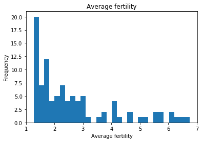

```python
# creates average fertility histogram
ax= merged_inner['Average_fert'].plot.hist(bins=30,title='Average fertility')

# sets the label of x axes
ax.set_xlabel('Average fertility',fontsize = 10); #xlabel;
```

The fertility data is skewed to the right

Then lets have a look at the average acohol consumption data

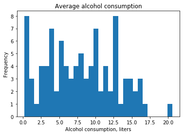

```python
# creates average fertility alcohol consumption histogram
ax=merged_inner['Average_alc'].plot.hist(bins=30,title='Average alcohol consumption')

# sets the label of x axes
ax.set_xlabel('Alcohol consumption, liters',fontsize = 10);
```

The destribution is seems to be normal with the peaking values of 0, 10 and 12,5

And tobacco...

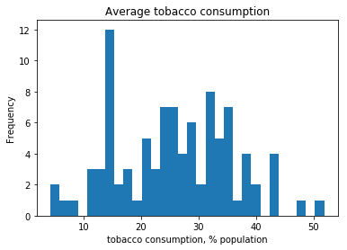

```python
# creates average fertility alcohol consumption histogram
ax=merged_inner['Average_tbc'].plot.hist(bins=30,title='Average tobacco consumption')

# sets the label of x axes
ax.set_xlabel('tobacco consumption, % population',fontsize = 10);
```

The destribution looks normal with the peaking value of 15

And car crash statistics...

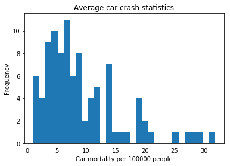

```python
# creates average fertility alcohol consumption histogram
ax= merged_inner['Average_car'].plot.hist(bins=30,title='Average car crash statistics' )

# sets the label of x axes
ax.set_xlabel('Car mortality per 100000 people',fontsize = 10);
```

Car crash statistics is skewed to the right as well

Then alc vs. tobacco

How about scatter plot with a trend line for tobacco vs alcohol consumption? This will give the sense if there is any correlation between two values

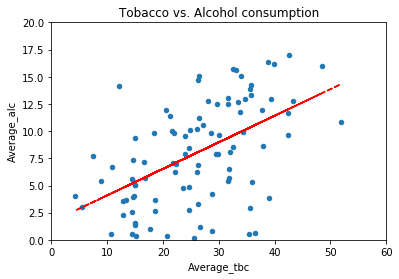

```python
#creates a scatter plot for average tobacco and alcohol consumption
ax = merged_inner.plot(kind='scatter',x='Average_tbc', y='Average_alc', title='Tobacco vs. Alcohol consumption')

#Sets x and y axes limits
ax.set_ylim(0,20)
ax.set_xlim(0,60)

#Sets x and y axes labels
ax.set_xlabel('Average_tbc',fontsize = 10) #xlabel
ax.set_ylabel('Average_alc', fontsize = 10); #ylabel

# This block uses Numpy to create the trendline to show correlation between factors
z = np.polyfit(merged_inner['Average_tbc'], merged_inner['Average_alc'], 1)
p = np.poly1d(z)

# Plots trendline
plt.plot(merged_inner['Average_tbc'],p(merged_inner['Average_tbc']),"r--");
```

It looks like we have a positive correlation between tobacco and alcohol correlation

How about scatter plot with a trend line for fertility vs alcohol consumption? This will give the sense if there is any correlation between two values

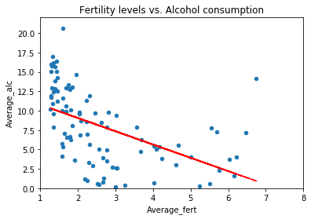

```python
#creates a scatter plot for fertility and alcohol consumption
ax = merged_inner.plot(kind='scatter',x='Average_fert', y='Average_alc', title='Fertility levels vs. Alcohol consumption')

#Sets x and y axes limits
ax.set_ylim(0,22)
ax.set_xlim(1,8)

#Sets x and y axes labels
ax.set_xlabel('Average_fert',fontsize = 10) #xlabel
ax.set_ylabel('Average_alc', fontsize = 10); #ylabel

# This block uses Numpy to create the trendline to show correlation between factors
z = np.polyfit(merged_inner['Average_fert'], merged_inner['Average_alc'], 1)
p = np.poly1d(z)

# Plots trendline
plt.plot(merged_inner['Average_fert'],p(merged_inner['Average_fert']),"r--");
```

There is a negative correlation between alcohol consumption and fertility

And fertility vs. tobacco consumption. Again to check the possible correlation

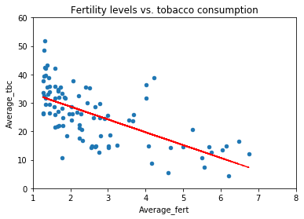

```python
#creates a scatter plot for tobacco consumption and fertility
ax = merged_inner.plot(kind='scatter',x='Average_fert', y='Average_tbc', title='Fertility levels vs. tobacco consumption')

#Sets x and y axes limits
ax.set_ylim(0,60)
ax.set_xlim(1,8)

#Sets x and y axes labels
ax.set_xlabel('Average_fert',fontsize = 10) #xlabel
ax.set_ylabel('Average_tbc', fontsize = 10); #ylabel

# This block uses Numpy to create the trendline to show correlation between factors
z = np.polyfit(merged_inner['Average_fert'], merged_inner['Average_tbc'], 1)
p = np.poly1d(z)

# Plots trendline
plt.plot(merged_inner['Average_fert'],p(merged_inner['Average_fert']),"r--");
```

There is a negative correlation between tobacco consumption and fertility

Also it would be nice to take a look at car crash statistics vs. alcohol consumption correlation in scatter plot as it best fits our goal

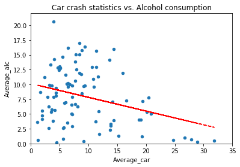

```python
#creates a scatter plot for tobacco and alcohol consumption
ax = merged_inner.plot(kind='scatter',x='Average_car', y='Average_alc', title='Car crash statistics vs. Alcohol consumption')

#Sets x and y axes limits
ax.set_ylim(0,22)
ax.set_xlim(0,35)

#Sets x and y axes labels
ax.set_xlabel('Average_car',fontsize = 10) #xlabel
ax.set_ylabel('Average_alc', fontsize = 10); #ylabel

# This block uses Numpy to create the trendline to show correlation between factors
z = np.polyfit(merged_inner['Average_car'], merged_inner['Average_alc'], 1)
p = np.poly1d(z)

# Plots trendline
plt.plot(merged_inner['Average_car'],p(merged_inner['Average_car']),"r--");
```

There is a negative correlation between alcohol consumption and car crash statistics

Also it would be nice to take a look at car crash statistics vs. tobacco consumption correlation in scatter plot as it best fits our goal

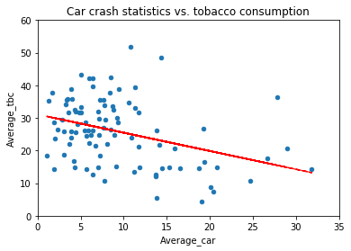

```python
#creates a scatter plot for tobacco consumption and car crash statistics
ax = merged_inner.plot(kind='scatter',x='Average_car', y='Average_tbc', title='Car crash statistics vs. tobacco consumption')

#Sets x and y axes limits
ax.set_ylim(0,60)
ax.set_xlim(0,35)

#Sets x and y axes labels
ax.set_xlabel('Average_car',fontsize = 10) #xlabel
ax.set_ylabel('Average_tbc', fontsize = 10); #ylabel

# This block uses Numpy to create the trendline to show correlation between factors
z = np.polyfit(merged_inner['Average_car'], merged_inner['Average_tbc'], 1)
p = np.poly1d(z)

# Plots trendline
plt.plot(merged_inner['Average_car'],p(merged_inner['Average_car']),"r--");
```

There is a negative correlation between tobacco consumption and car crash statistics

### 1) What countries that have the lowest/highest GDP have lowest/highest average fertility level? How does it correspond to acohol or tobacco consumption data? Is this affected by GDP?

Now, when we had acquainted with all variables it would be nice to add another one - The GDP levels. In order to accomplish this we need to create a colorful bubble plot that will have spheres colored and sized ranging with the GDP level.

In order to answer that we should build the bubble plot to see the contries with lowest/highest GDP as bubbles. The size is dependant on the level of GDP defined in previous section.

NOTE:

- Fertility rate is measured as children per women
- Alcohol consumption is measured as consumption per adult in liters
- Tobacco consumption is measured as prevalence of current tobacco use among adults (%) both sexes
- Car crash statistics is measured as Car road traffic mortality, age adjusted, per 100 000

First we define colors.

```python
## Each number is taken from Average GDP column and then turned to color code respectively
colors = {1:'red', 2:'olive', 3:'blue', 4:'green'}

#populates color codes according to GDP levels
ca=merged_inner['Average_gdp'].apply(lambda x: colors[x])
```

Then we need to create sub categories based on GDP levels which will be used as s parameter in bubble plots.

```python
#Takes contries with GDP level 1 and assigns color from colors dict
cond1 = merged_inner.loc[merged_inner['Average_gdp'] == 1]## Contries with lowest GDP
ca1=cond1['Average_gdp'].apply(lambda x: colors[x])

#Takes contries with GDP level 2 and assigns color from colors dict
cond2 = merged_inner.loc[merged_inner['Average_gdp'] == 2]
ca2=cond2['Average_gdp'].apply(lambda x: colors[x])

#Takes contries with GDP level 3 and assigns color from colors dict
cond3 = merged_inner.loc[merged_inner['Average_gdp'] == 3]
ca3=cond3['Average_gdp'].apply(lambda x: colors[x])

#Takes contries with GDP level 4 and assigns color from colors dict
cond4 = merged_inner.loc[merged_inner['Average_gdp'] == 4]## Contries with highest GDP
ca4=cond4['Average_gdp'].apply(lambda x: colors[x])
```

### AVERAGE VALUES fertility vs alcohol consumption

Ok, lets get it started with plotting the average values for all contries in our list with annotations as bubble plots.

colors = {1:'red', 2:'olive', 3:'blue', 4:'green'}

The whole data set is chosen to be shown as a bubble plot as it gives the most sense of data distribution where we can see relation between three variables.

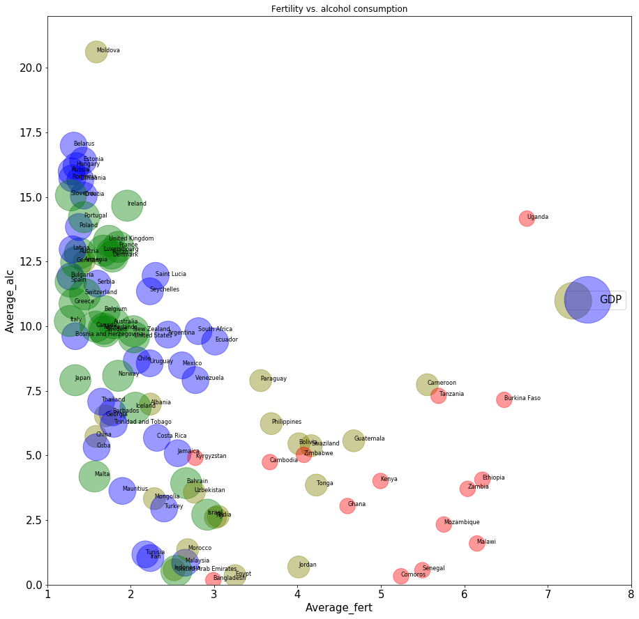

```python
# Creates a scatter plot that uses GDP levels to set colors and bubble sizes
ax=merged_inner.plot.scatter(x='Average_fert',y= 'Average_alc', c=ca,s = merged_inner['Average_gdp']*500,
                             alpha=0.4,figsize=(15,15),fontsize=15,label ='GDP', title='Fertility vs. alcohol consumption')

## Creates annotation for each contry
for i, txt in enumerate(merged_inner.cntry):
    ax.annotate(txt, (merged_inner['Average_fert'].iat[i],merged_inner['Average_alc'].iat[i]),fontsize=8 )

# Creates legend
ax.legend(scatterpoints=2,loc='right',ncol=1,markerscale=1.5,fontsize=15)

#Sets x and y axes labels
ax.set_xlabel('Average_fert',fontsize = 15) #xlabel
ax.set_ylabel('Average_alc', fontsize = 15)#ylabel

#Sets x and y axes limits
ax.set_ylim(0,22)
ax.set_xlim(1,8);
```

This plot shows the destribution of data across the whole contry list with all the GDP. Here we can see that:

- The lowest GDP county with highest fertility - Uganda and lowest fertility is in Kyrgystan.
- The highest GDP contry with highest fertility - Israel and lowest fertility are Slovenia, Italy and Spain
- The data investigation revieled that the most alcohol consumption is concentrated in contries with the higher income (levels 2,3 and 4). In addition these contries tend to have lower fertility levels.

Combined bubble plot looks a bit messy, so I've desided to plot the GDP levels contries separately. This is GDP level 1

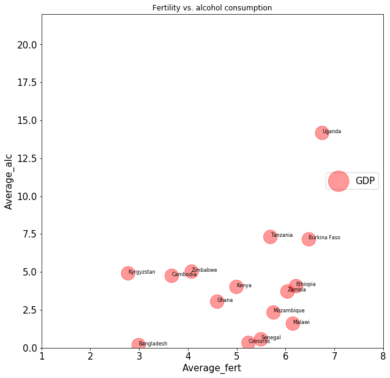

```python
# Creates a scatter plot that uses GDP levels to set colors and bubble sizes
ax=cond1 \
.plot.scatter(x='Average_fert',y= 'Average_alc',c=ca1,s = cond1['Average_gdp']*500,\
alpha=0.4,figsize=(10,10),fontsize=15,label ='GDP', title='Fertility vs. alcohol consumption')

## Creates annotation for each contry
for i, txt in enumerate(cond1.cntry):
    ax.annotate(txt, (cond1['Average_fert'].iat[i],cond1['Average_alc'].iat[i]),fontsize=8 )

# Creates legend
ax.legend(scatterpoints=1,loc='right',ncol=1,markerscale=1.5,fontsize=15)

#Sets x and y axes labels
ax.set_xlabel('Average_fert',fontsize = 15) #xlabel
ax.set_ylabel('Average_alc', fontsize = 15)#ylabel

#Sets x and y axes limits
ax.set_ylim(0,22)
ax.set_xlim(1,8);
```

This is the same part of the main bubble plot and answer the same questions so please refer to reasoning and explanation to paragraph with the combined bubble plot.

Combined bubble plot looks a bit messy, so I've desided to plot the GDP levels contries separately. This is GDP level 2

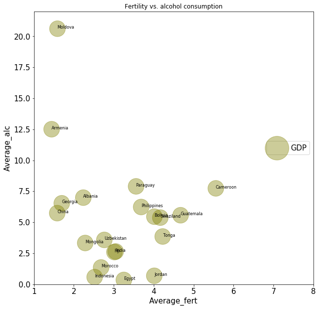

```python
# Creates a scatter plot that uses GDP levels to set colors and bubble sizes
ax=cond2 \
.plot.scatter(x='Average_fert',y= 'Average_alc',c=ca2,s = cond2['Average_gdp']*500,\
alpha=0.4,figsize=(10,10),fontsize=15,label ='GDP', title='Fertility vs. alcohol consumption')

## Creates annotation for each contry
for i, txt in enumerate(cond2.cntry):
    ax.annotate(txt, (cond2['Average_fert'].iat[i],cond2['Average_alc'].iat[i]),fontsize=8 )

# Creates legend
ax.legend(scatterpoints=1,loc='right',ncol=1,markerscale=1.5,fontsize=15)

#Sets x and y axes labels
ax.set_xlabel('Average_fert',fontsize = 15) #xlabel
ax.set_ylabel('Average_alc', fontsize = 15)#ylabel

#Sets x and y axes limits
ax.set_ylim(0,22)
ax.set_xlim(1,8);
```

This is the same part of the main bubble plot and answer the same questions so please refer to reasoning and explanation to paragraph with the combined bubble plot.

Combined bubble plot looks a bit messy, so I've desided to plot the GDP levels contries separately. This is GDP level 3

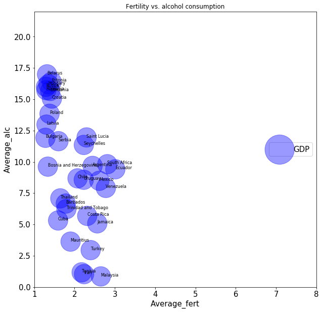

```python
# Creates a scatter plot that uses GDP levels to set colors and bubble sizes
ax=cond3 \
.plot.scatter(x='Average_fert',y= 'Average_alc',c=ca3,s = cond3['Average_gdp']*500,\
alpha=0.4,figsize=(10,10),fontsize=15,label ='GDP', title='Fertility vs. alcohol consumption')

## Creates annotation for each contry
for i, txt in enumerate(cond3.cntry):
    ax.annotate(txt, (cond3['Average_fert'].iat[i],cond3['Average_alc'].iat[i]),fontsize=8 )

# Creates legend
ax.legend(scatterpoints=1,loc='right',ncol=1,markerscale=1.5,fontsize=15)

#Sets x and y axes labels
ax.set_xlabel('Average_fert',fontsize = 15) #xlabel
ax.set_ylabel('Average_alc', fontsize = 15)#ylabel

#Sets x and y axes limits
ax.set_ylim(0,22)
ax.set_xlim(1,8);
```

This is the same part of the main bubble plot and answer the same questions so please refer to reasoning and explanation to paragraph with the combined bubble plot.

Combined bubble plot looks a bit messy, so I've desided to plot the GDP levels contries separately. This is GDP level 4

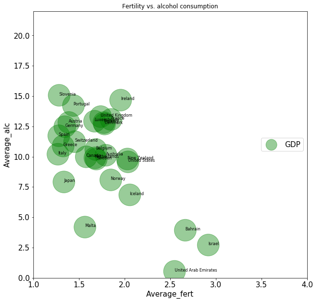

```python
# Creates a scatter plot that uses GDP levels to set colors and bubble sizes
ax=cond4 \
.plot.scatter(x='Average_fert',y= 'Average_alc',c=ca4,s = cond4['Average_gdp']*500,\
alpha=0.4,figsize=(10,10),fontsize=15,label ='GDP', title='Fertility vs. alcohol consumption')

## Creates annotation for each contry
for i, txt in enumerate(cond4.cntry):
    ax.annotate(txt, (cond4['Average_fert'].iat[i],cond4['Average_alc'].iat[i]),fontsize=8 )

# Creates legend
ax.legend(scatterpoints=1,loc='right',ncol=1,markerscale=0.5,fontsize=15)

#Sets x and y axes labels
ax.set_xlabel('Average_fert',fontsize = 15) #xlabel
ax.set_ylabel('Average_alc', fontsize = 15)#ylabel

#Sets x and y axes limits
ax.set_ylim(0,22)
ax.set_xlim(1,4);
```

This is the same part of the main bubble plot and answer the same questions so please refer to reasoning and explanation to paragraph with the combined bubble plot.

### AVERAGE VALUES for fertility vs tobacco consumption

Now lets take a look at the relationship between fertility and tobacco consumption. The worflow is the same as with fertility and alcohol consumption. We need to get the better sense of data hence the bubble plot was chosen to best outline the relation between three variables.

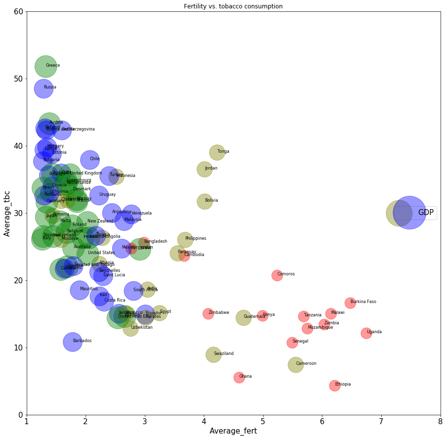

```python
# Creates a scatter plot that uses GDP levels to set colors and bubble sizes
ax=merged_inner.plot.scatter(x='Average_fert',y= 'Average_tbc', c=ca,s = merged_inner['Average_gdp']*500,
                             alpha=0.4,figsize=(15,15),fontsize=15,label ='GDP', title='Fertility vs. tobacco consumption')

## Creates annotation for each contry
for i, txt in enumerate(merged_inner.cntry):
    ax.annotate(txt, (merged_inner['Average_fert'].iat[i],merged_inner['Average_tbc'].iat[i]),fontsize=8 )

# Creates legend
ax.legend(scatterpoints=2,loc='right',ncol=1,markerscale=1.5,fontsize=15)

#Sets x and y axes labels
ax.set_xlabel('Average_fert',fontsize = 15) #xlabel
ax.set_ylabel('Average_tbc', fontsize = 15)#ylabel

#Sets x and y axes limits
ax.set_ylim(0,60)
ax.set_xlim(1,8);
```

This plot shows the destribution of data across the whole contry list with all the GDP. Here we can see that:

- The lowest GDP county with highest fertility - Uganda and lowest fertility is in Kyrgystan.
- The highest GDP contry with highest fertility - Israel and lowest fertility are Slovenia, Italy and Spain
- The data investigation revieled that the most tobacco consumption is concentrated in contries with the higher income (levels 2,3 and 4). In addition these contries tend to have lower fertility levels.

Combined bubble plot looks a bit messy, so I've desided to plot the GDP levels contries separately. This is GDP level 1

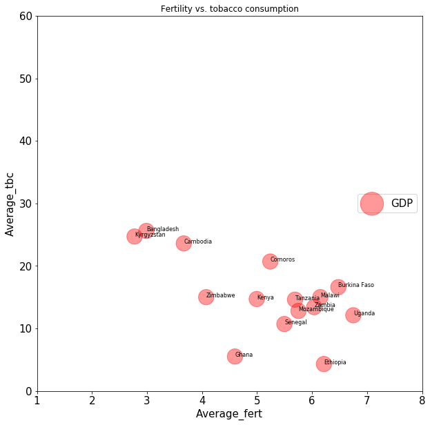

```python
# Creates a scatter plot that uses GDP levels to set colors and bubble sizes
ax=cond1 \
.plot.scatter(x='Average_fert',y= 'Average_tbc',c=ca1,s = cond1['Average_gdp']*500,\
alpha=0.4,figsize=(10,10),fontsize=15,label ='GDP', title='Fertility vs. tobacco consumption')

## Creates annotation for each contry
for i, txt in enumerate(cond1.cntry):
    ax.annotate(txt, (cond1['Average_fert'].iat[i],cond1['Average_tbc'].iat[i]),fontsize=8 )

# Creates legend
ax.legend(scatterpoints=1,loc='right',ncol=1,markerscale=1.5,fontsize=15)

#Sets x and y axes labels
ax.set_xlabel('Average_fert',fontsize = 15) #xlabel
ax.set_ylabel('Average_tbc', fontsize = 15)#ylabel

#Sets x and y axes limits
ax.set_ylim(0,60)
ax.set_xlim(1,8);
```

This is the same part of the main bubble plot and answer the same questions so please refer to reasoning and explanation to paragraph with the combined bubble plot.

Combined bubble plot looks a bit messy, so I've desided to plot the GDP levels contries separately. This is GDP level 2

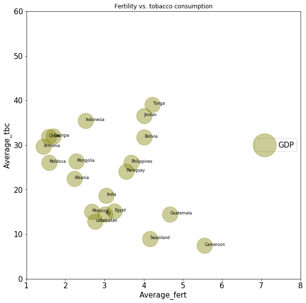

```python
# Creates a scatter plot that uses GDP levels to set colors and bubble sizes
ax=cond2 \
.plot.scatter(x='Average_fert',y= 'Average_tbc',c=ca2,s = cond2['Average_gdp']*500,\
alpha=0.4,figsize=(10,10),fontsize=15,label ='GDP', title='Fertility vs. tobacco consumption')

## Creates annotation for each contry
for i, txt in enumerate(cond2.cntry):
    ax.annotate(txt, (cond2['Average_fert'].iat[i],cond2['Average_tbc'].iat[i]),fontsize=8 )

# Creates legend
ax.legend(scatterpoints=1,loc='right',ncol=1,markerscale=1.5,fontsize=15)

#Sets x and y axes labels
ax.set_xlabel('Average_fert',fontsize = 15) #xlabel
ax.set_ylabel('Average_tbc', fontsize = 15)#ylabel

#Sets x and y axes limits
ax.set_ylim(0,60)
ax.set_xlim(1,8);
```

This is the same part of the main bubble plot and answer the same questions so please refer to reasoning and explanation to paragraph with the combined bubble plot.

Combined bubble plot looks a bit messy, so I've desided to plot the GDP levels contries separately. This is GDP level 3

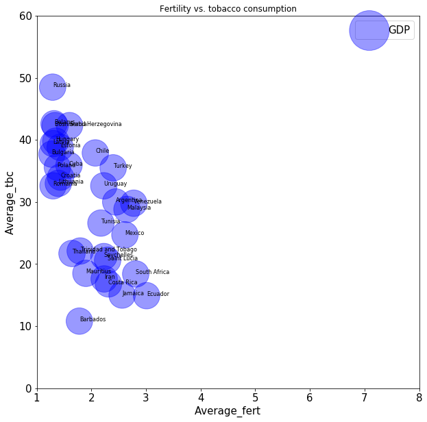

```python
# Creates a scatter plot that uses GDP levels to set colors and bubble sizes
ax=cond3 \
.plot.scatter(x='Average_fert',y= 'Average_tbc',c=ca3,s = cond3['Average_gdp']*500,\
alpha=0.4,figsize=(10,10),fontsize=15,label ='GDP', title='Fertility vs. tobacco consumption')

## Creates annotation for each contry
for i, txt in enumerate(cond3.cntry):
    ax.annotate(txt, (cond3['Average_fert'].iat[i],cond3['Average_tbc'].iat[i]),fontsize=8 )

# Creates legend
ax.legend(scatterpoints=1,loc='best',ncol=1,markerscale=1.5,fontsize=15)

#Sets x and y axes labels
ax.set_xlabel('Average_fert',fontsize = 15) #xlabel
ax.set_ylabel('Average_tbc', fontsize = 15)#ylabel

#Sets x and y axes limits
ax.set_ylim(0,60)
ax.set_xlim(1,8);
```

This is the same part of the main bubble plot and answer the same questions so please refer to reasoning and explanation to paragraph with the combined bubble plot.

Combined bubble plot looks a bit messy, so I've desided to plot the GDP levels contries separately. This is GDP level 4

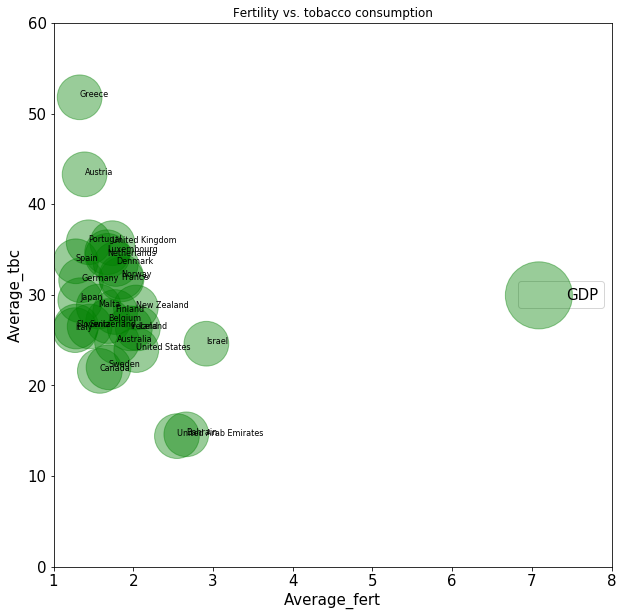

```python
# Creates a scatter plot that uses GDP levels to set colors and bubble sizes
ax=cond4 \
.plot.scatter(x='Average_fert',y= 'Average_tbc',c=ca4,s = cond4['Average_gdp']*500,\
alpha=0.4,figsize=(10,10),fontsize=15,label ='GDP', title='Fertility vs. tobacco consumption')

## Creates annotation for each contry
for i, txt in enumerate(cond4.cntry):
    ax.annotate(txt, (cond4['Average_fert'].iat[i],cond4['Average_tbc'].iat[i]),fontsize=8 )

# Creates legend
ax.legend(scatterpoints=1,loc='right',ncol=1,markerscale=1.5,fontsize=15)

#Sets x and y axes labels
ax.set_xlabel('Average_fert',fontsize = 15) #xlabel
ax.set_ylabel('Average_tbc', fontsize = 15)#ylabel

#Sets x and y axes limits
ax.set_ylim(0,60)
ax.set_xlim(1,8);
```

This is the same part of the main bubble plot and answer the same questions so please refer to reasoning and explanation to paragraph with the combined bubble plot.

### AVERAGE VALUES cars vs alcohol

The bubble plot of car crash statistics vs alcohol consumption is chosen to best outline the relationship nbetween these two values and GDP

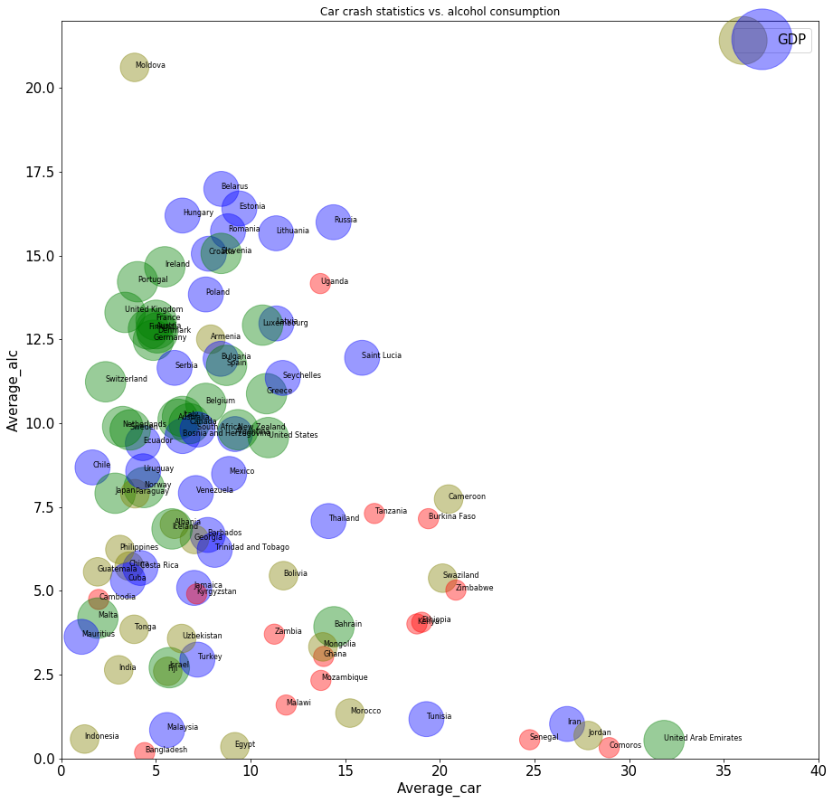

```python
# Creates a scatter plot that uses GDP levels to set colors and bubble sizes
ax=merged_inner.plot.scatter(x='Average_car',y= 'Average_alc', c=ca,s = merged_inner['Average_gdp']*500, \
        alpha=0.4,figsize=(15,15),fontsize=15,label ='GDP', title='Car crash statistics vs. alcohol consumption')
## Creates annotation for each contry
for i, txt in enumerate(merged_inner.cntry):
    ax.annotate(txt, (merged_inner['Average_car'].iat[i],merged_inner['Average_alc'].iat[i]),fontsize=8 )

# Creates legend
ax.legend(scatterpoints=2,loc='best',ncol=1,markerscale=1.5,fontsize=15)

#Sets x and y axes labels
ax.set_xlabel('Average_car',fontsize = 15) #xlabel
ax.set_ylabel('Average_alc', fontsize = 15)#ylabel

#Sets x and y axes limits
ax.set_ylim(0,22)
ax.set_xlim(0,40);
```

This plot shows the destribution of data across the whole contry list with all the GDP. Here we can see that:

- The lowest GDP county with highest car mortality - Comoros and lowest car mortality is in Combodia.
- The highest GDP contry with highest car mortality - United Arab Emirates and lowest car mortality is in Malta
- The data investigation revieled that the most alcohol consumption is concentrated in contries with the higher income (levels 2,3 and 4). The most car mortality levels seem to be also spread across these contries .

Combined bubble plot looks a bit messy, so I've desided to plot the GDP levels contries separately. This is GDP level 1

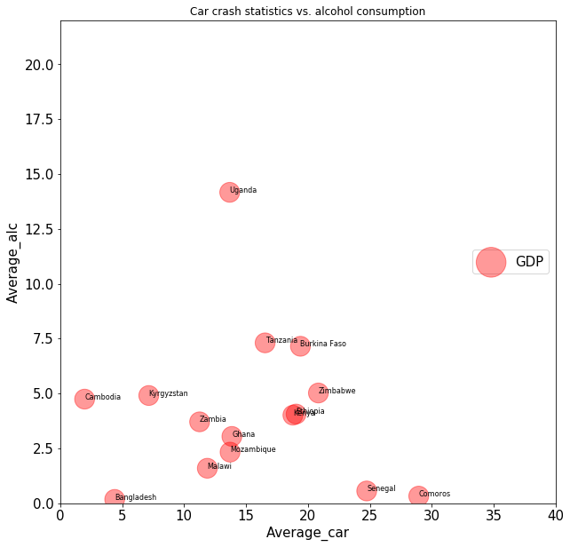

```python
# Creates a scatter plot that uses GDP levels to set colors and bubble sizes
ax=cond1 \
.plot.scatter(x='Average_car',y= 'Average_alc',c=ca1,s = cond1['Average_gdp']*500,\
alpha=0.4,figsize=(10,10),fontsize=15,label ='GDP', title='Car crash statistics vs. alcohol consumption')

## Creates annotation for each contry
for i, txt in enumerate(cond1.cntry):
    ax.annotate(txt, (cond1['Average_car'].iat[i],cond1['Average_alc'].iat[i]),fontsize=8 )

# Creates legend
ax.legend(scatterpoints=1,loc='right',ncol=1,markerscale=1.5,fontsize=15)

#Sets x and y axes labels
ax.set_xlabel('Average_car',fontsize = 15) #xlabel
ax.set_ylabel('Average_alc', fontsize = 15)#ylabel

#Sets x and y axes limits
ax.set_ylim(0,22)
ax.set_xlim(0,40);
```

This is the same part of the main bubble plot and answer the same questions so please refer to reasoning and explanation to paragraph with the combined bubble plot.

Combined bubble plot looks a bit messy, so I've desided to plot the GDP levels contries separately. This is GDP level 2

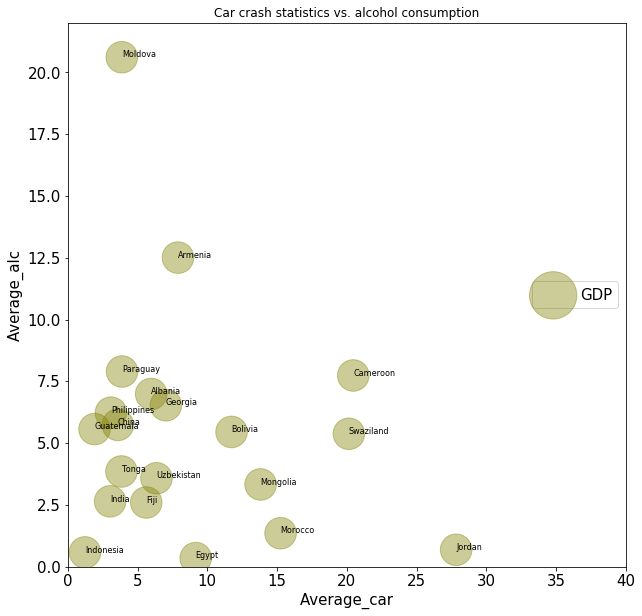

```python
# Creates a scatter plot that uses GDP levels to set colors and bubble sizes
ax=cond2 \
.plot.scatter(x='Average_car',y= 'Average_alc',c=ca2,s = cond2['Average_gdp']*500,\
alpha=0.4,figsize=(10,10),fontsize=15,label ='GDP', title='Car crash statistics vs. alcohol consumption')

## Creates annotation for each contry
for i, txt in enumerate(cond2.cntry):
    ax.annotate(txt, (cond2['Average_car'].iat[i],cond2['Average_alc'].iat[i]),fontsize=8 )

# Creates legend
ax.legend(scatterpoints=1,loc='right',ncol=1,markerscale=1.5,fontsize=15)

#Sets x and y axes labels
ax.set_xlabel('Average_car',fontsize = 15) #xlabel
ax.set_ylabel('Average_alc', fontsize = 15)#ylabel

#Sets x and y axes limits
ax.set_ylim(0,22)
ax.set_xlim(0,40);
```

This is the same part of the main bubble plot and answer the same questions so please refer to reasoning and explanation to paragraph with the combined bubble plot.

Combined bubble plot looks a bit messy, so I've desided to plot the GDP levels contries separately. This is GDP level 3

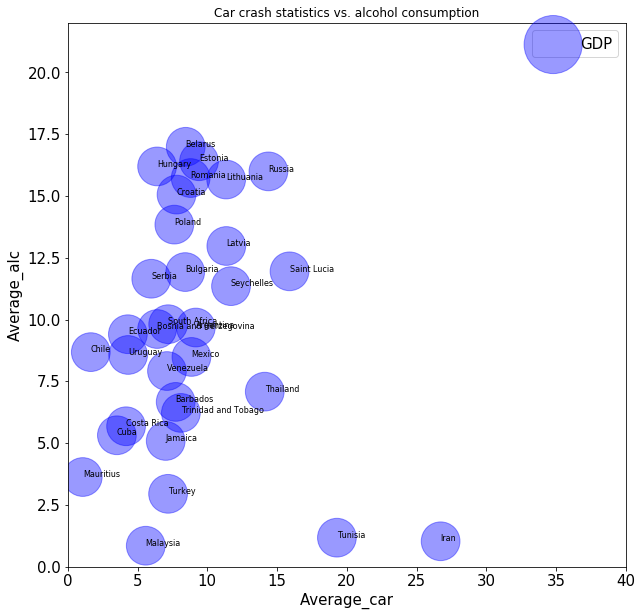

```python
# Creates a scatter plot that uses GDP levels to set colors and bubble sizes
ax=cond3 \
.plot.scatter(x='Average_car',y= 'Average_alc',c=ca3,s = cond3['Average_gdp']*500,\
alpha=0.4,figsize=(10,10),fontsize=15,label ='GDP', title='Car crash statistics vs. alcohol consumption')

## Creates annotation for each contry
for i, txt in enumerate(cond3.cntry):
    ax.annotate(txt, (cond3['Average_car'].iat[i],cond3['Average_alc'].iat[i]),fontsize=8 )

# Creates legend
ax.legend(scatterpoints=1,loc='best',ncol=1,markerscale=1.5,fontsize=15)

#Sets x and y axes labels
ax.set_xlabel('Average_car',fontsize = 15) #xlabel
ax.set_ylabel('Average_alc', fontsize = 15)#ylabel

#Sets x and y axes limits
ax.set_ylim(0,22)
ax.set_xlim(0,40);
```

This is the same part of the main bubble plot and answer the same questions so please refer to reasoning and explanation to paragraph with the combined bubble plot.

Combined bubble plot looks a bit messy, so I've desided to plot the GDP levels contries separately. This is GDP level 4

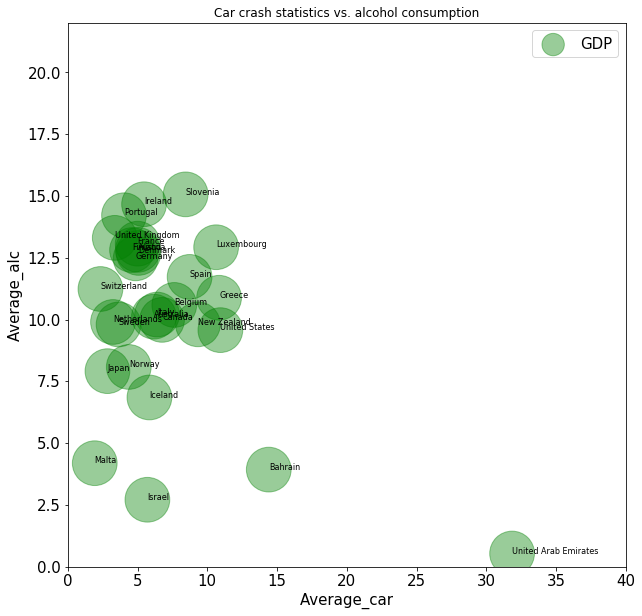

```python
# Creates a scatter plot that uses GDP levels to set colors and bubble sizes
ax=cond4 \
.plot.scatter(x='Average_car',y= 'Average_alc',c=ca4,s = cond4['Average_gdp']*500,\
alpha=0.4,figsize=(10,10),fontsize=15,label ='GDP', title='Car crash statistics vs. alcohol consumption')

## Creates annotation for each contry
for i, txt in enumerate(cond4.cntry):
    ax.annotate(txt, (cond4['Average_car'].iat[i],cond4['Average_alc'].iat[i]),fontsize=8 )

# Creates legend
ax.legend(scatterpoints=1,loc='best',ncol=1,markerscale=0.5,fontsize=15)

#Sets x and y axes labels
ax.set_xlabel('Average_car',fontsize = 15) #xlabel
ax.set_ylabel('Average_alc', fontsize = 15)#ylabel

#Sets x and y axes limits
ax.set_ylim(0,22)
ax.set_xlim(0,40);
```

This is the same part of the main bubble plot and answer the same questions so please refer to reasoning and explanation to paragraph with the combined bubble plot.

Combined bubble plot looks a bit messy, so I've desided to plot the GDP levels contries separately.

### AVERAGE VALUES cars vs tobacco

The bubble plot of car crash statistics vs tobacco consumption is chosen to best outline the relationship nbetween these two values and GDP

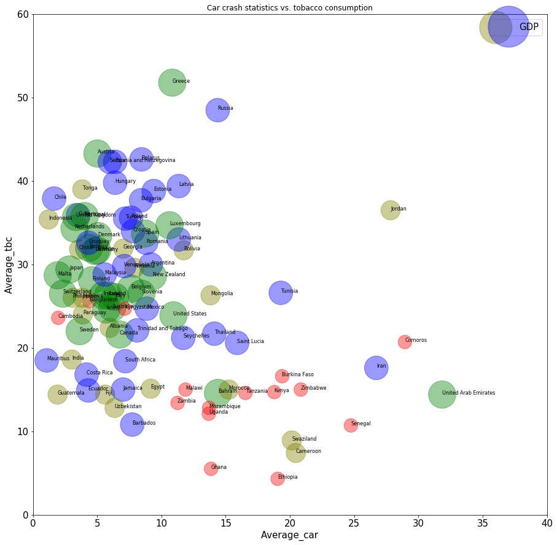

```python
# Creates a scatter plot that uses GDP levels to set colors and bubble sizes
ax=merged_inner.plot.scatter(x='Average_car',y= 'Average_tbc', c=ca,s = merged_inner['Average_gdp']*500, \
        alpha=0.4,figsize=(15,15),fontsize=15,label ='GDP', title='Car crash statistics vs. tobacco consumption')
## Creates annotation for each contry
for i, txt in enumerate(merged_inner.cntry):
    ax.annotate(txt, (merged_inner['Average_car'].iat[i],merged_inner['Average_tbc'].iat[i]),fontsize=8 )

# Creates legend
ax.legend(scatterpoints=2,loc='best',ncol=1,markerscale=1.5,fontsize=15)

#Sets x and y axes labels
ax.set_xlabel('Average_car',fontsize = 15) #xlabel
ax.set_ylabel('Average_tbc', fontsize = 15)#ylabel

#Sets x and y axes limits
ax.set_ylim(0,60)
ax.set_xlim(0,40);
```

This plot shows the destribution of data across the whole contry list with all the GDP. Here we can see that:

- The lowest GDP county with highest car mortality - Comoros and lowest car mortality is in Combodia.
- The highest GDP contry with highest car mortality - United Arab Emirates and lowest car mortality is in Malta
- The data investigation revieled that the most tobacco consumption is concentrated in contries with the higher income (levels 2,3 and 4). The most car mortality levels seem to be also spread across these contries .

Combined bubble plot looks a bit messy, so I've desided to plot the GDP levels contries separately. This is GDP level 1

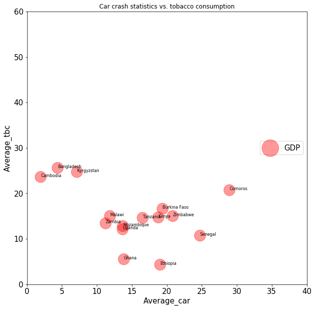

```python
# Creates a scatter plot that uses GDP levels to set colors and bubble sizes
ax=cond1 \
.plot.scatter(x='Average_car',y= 'Average_tbc',c=ca1,s = cond1['Average_gdp']*500,\
alpha=0.4,figsize=(10,10),fontsize=15,label ='GDP', title='Car crash statistics vs. tobacco consumption')

## Creates annotation for each contry
for i, txt in enumerate(cond1.cntry):
    ax.annotate(txt, (cond1['Average_car'].iat[i],cond1['Average_tbc'].iat[i]),fontsize=8 )

# Creates legend
ax.legend(scatterpoints=1,loc='right',ncol=1,markerscale=1.5,fontsize=15)

#Sets x and y axes labels
ax.set_xlabel('Average_car',fontsize = 15) #xlabel
ax.set_ylabel('Average_tbc', fontsize = 15)#ylabel

#Sets x and y axes limits
ax.set_ylim(0,60)
ax.set_xlim(0,40);
```

This is the same part of the main bubble plot and answer the same questions so please refer to reasoning and explanation to paragraph with the combined bubble plot.

Combined bubble plot looks a bit messy, so I've desided to plot the GDP levels contries separately. This is GDP level 2

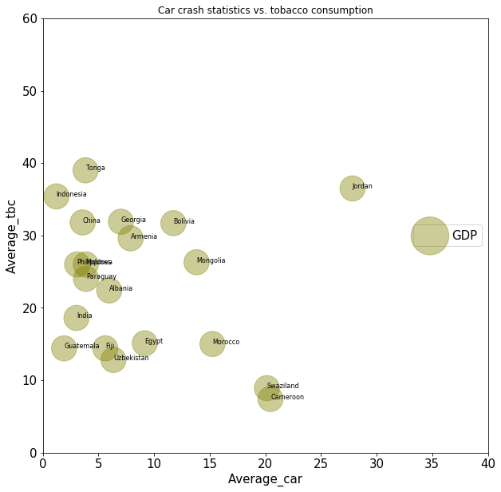

```python
# Creates a scatter plot that uses GDP levels to set colors and bubble sizes
ax=cond2 \
.plot.scatter(x='Average_car',y= 'Average_tbc',c=ca2,s = cond2['Average_gdp']*500,\
alpha=0.4,figsize=(10,10),fontsize=15,label ='GDP', title='Car crash statistics vs. tobacco consumption')

## Creates annotation for each contry
for i, txt in enumerate(cond2.cntry):
    ax.annotate(txt, (cond2['Average_car'].iat[i],cond2['Average_tbc'].iat[i]),fontsize=8 )

# Creates legend
ax.legend(scatterpoints=1,loc='right',ncol=1,markerscale=1.5,fontsize=15)

#Sets x and y axes labels
ax.set_xlabel('Average_car',fontsize = 15) #xlabel
ax.set_ylabel('Average_tbc', fontsize = 15)#ylabel

#Sets x and y axes limits
ax.set_ylim(0,60)
ax.set_xlim(0,40);
```

This is the same part of the main bubble plot and answer the same questions so please refer to reasoning and explanation to paragraph with the combined bubble plot.

Combined bubble plot looks a bit messy, so I've desided to plot the GDP levels contries separately. This is GDP level 3

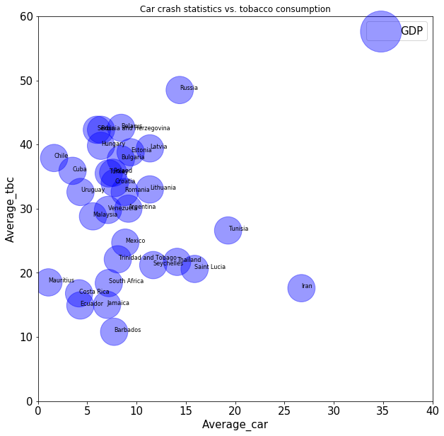

```python
# Creates a scatter plot that uses GDP levels to set colors and bubble sizes
ax=cond3 \
.plot.scatter(x='Average_car',y= 'Average_tbc',c=ca3,s = cond3['Average_gdp']*500,\
alpha=0.4,figsize=(10,10),fontsize=15,label ='GDP', title='Car crash statistics vs. tobacco consumption')

## Creates annotation for each contry
for i, txt in enumerate(cond3.cntry):
    ax.annotate(txt, (cond3['Average_car'].iat[i],cond3['Average_tbc'].iat[i]),fontsize=8 )

# Creates legend
ax.legend(scatterpoints=1,loc='best',ncol=1,markerscale=1.5,fontsize=15)

#Sets x and y axes labels
ax.set_xlabel('Average_car',fontsize = 15) #xlabel
ax.set_ylabel('Average_tbc', fontsize = 15)#ylabel

#Sets x and y axes limits
ax.set_ylim(0,60)
ax.set_xlim(0,40);
```

This is the same part of the main bubble plot and answer the same questions so please refer to reasoning and explanation to paragraph with the combined bubble plot.

Combined bubble plot looks a bit messy, so I've desided to plot the GDP levels contries separately. This is GDP level 4

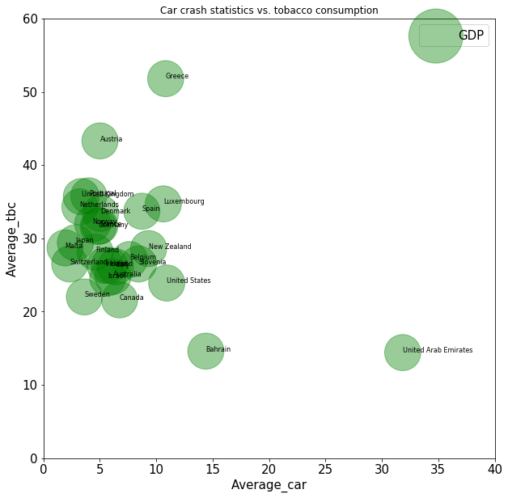

```python
# Creates a scatter plot that uses GDP levels to set colors and bubble sizes
ax=cond4 \
.plot.scatter(x='Average_car',y= 'Average_tbc',c=ca4,s = cond4['Average_gdp']*500,\
alpha=0.4,figsize=(10,10),fontsize=15,label ='GDP', title='Car crash statistics vs. tobacco consumption')

## Creates annotation for each contry
for i, txt in enumerate(cond4.cntry):
    ax.annotate(txt, (cond4['Average_car'].iat[i],cond4['Average_tbc'].iat[i]),fontsize=8 )

# Creates legend
ax.legend(scatterpoints=1,loc='best',ncol=1,markerscale=1.5,fontsize=15)

#Sets x and y axes labels
ax.set_xlabel('Average_car',fontsize = 15) #xlabel
ax.set_ylabel('Average_tbc', fontsize = 15)#ylabel

#Sets x and y axes limits
ax.set_ylim(0,60)
ax.set_xlim(0,40);
```

This is the same part of the main bubble plot and answer the same questions so please refer to reasoning and explanation to paragraph with the combined bubble plot.

### 3) What countries that have the lowest/highest GDP have lowest/highest alco/tobacco consumption and is there any correlation between high/low alcohol and tobacco consumption?

And finally lets take a look at tobacco-alcohol consumption destributions. Again the bubble plot was chose as it best gives the understanding of relationship between three studied values.

### AVERAGE VALUES tobacco vs alcohol

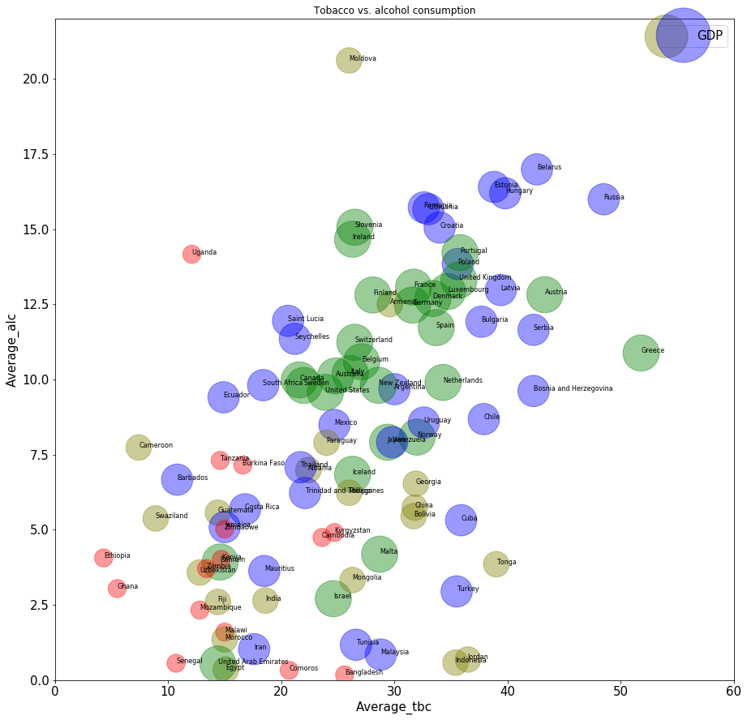

```python
# Creates a scatter plot that uses GDP levels to set colors and bubble sizes
ax=merged_inner.plot.scatter(x='Average_tbc',y= 'Average_alc', c=ca,s = merged_inner['Average_gdp']*500,\
        alpha=0.4, figsize=(15,15),fontsize=15,label ='GDP',title='Tobacco vs. alcohol consumption')

## Creates annotation for each contry
for i, txt in enumerate(merged_inner.cntry):
    ax.annotate(txt, (merged_inner['Average_tbc'].iat[i],merged_inner['Average_alc'].iat[i]),fontsize=8 )

# Creates legend
ax.legend(scatterpoints=2,loc='best',ncol=1,markerscale=1.5,fontsize=15)

#Sets x and y axes labels
ax.set_xlabel('Average_tbc',fontsize = 15) #xlabel
ax.set_ylabel('Average_alc', fontsize = 15)#ylabel

#Sets x and y axes limits
ax.set_ylim(0,22)
ax.set_xlim(0,60);
```

Combined bubble plot looks a bit messy, so I've desided to plot the GDP levels contries separately. This is GDP level 1

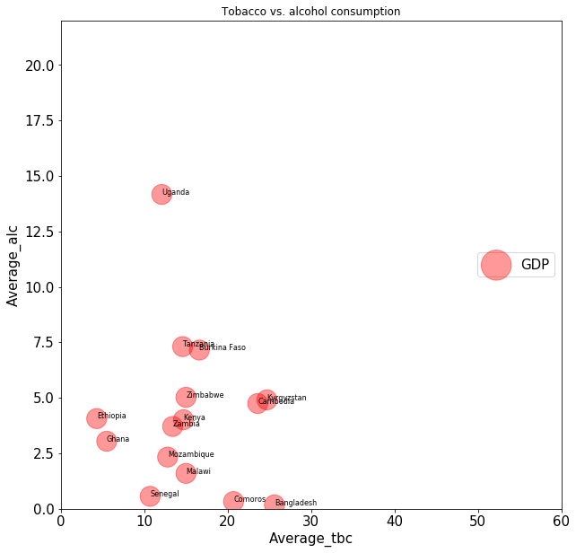

```python
# Creates a scatter plot that uses GDP levels to set colors and bubble sizes
ax=cond1 \
.plot.scatter(x='Average_tbc',y= 'Average_alc',c=ca1,s = cond1['Average_gdp']*500,\
alpha=0.4,figsize=(10,10),fontsize=15,label ='GDP',title='Tobacco vs. alcohol consumption')

## Creates annotation for each contry
for i, txt in enumerate(cond1.cntry):
    ax.annotate(txt, (cond1['Average_tbc'].iat[i],cond1['Average_alc'].iat[i]),fontsize=8 )

# Creates legend
ax.legend(scatterpoints=1,loc='right',ncol=1,markerscale=1.5,fontsize=15)

#Sets x and y axes labels
ax.set_xlabel('Average_tbc',fontsize = 15) #xlabel
ax.set_ylabel('Average_alc', fontsize = 15)#ylabel

#Sets x and y axes limits
ax.set_ylim(0,22)
ax.set_xlim(0,60);
```

This is the same part of the main bubble plot and answer the same questions so please refer to reasoning and explanation to paragraph with the combined bubble plot.